# Ejemplo R + Markdown + WordPress en español

José R. Ferrer Paris (@jrfep)

Enero 2, 2019

La versatilidad de [R](https://cran.r-project.org/) permite integrar los análisis matemáticos y estadísticos en flujos de trabajo complejos. Sin embargo usualmente unas pocas líneas de código es todo lo que se necesita para resolver problemas sencillos pero recurrentes.

Es útil tener a la mano estos códigos para poder reutilizarlos, y mejor aún si adjuntamos una explicación concisa de su utilidad y los pasos necesarios, de tal forma que podamos reconstruir y mejorar su funcionalidad.

Anteriormente he utilizado Sweave para generar documentos y reportes en formato pdf, algunos de los cuales tengo publicados en mi perfil de [fig**share**](https://figshare.com/authors/Jos_R_Ferrer-Paris/592994). Sin embargo, al empezar a administrar mi sitio web empecé a buscar otras herramientas que me permitieran generar código html para ingresarlo directamente al manejador de contenido de WordPress.

Este es mi primer intento de publicar en WordPress desde una sesión de R usando los paquetes [**knitr**](https://yihui.name/knitr/) y [**RWordPress**](https://github.com/duncantl/RWordPress), siguiendo las recomendaciones de otros usuarios como [yihui](https://yihui.name/knitr/demo/wordpress/), [3.14a](http://3.14a.ch/archives/2015/03/08/how-to-publish-with-r-markdown-in-wordpress/) y [Heather Urry](http://sites.tufts.edu/emotiononthebrain/2017/08/12/blog-posting-from-r-markdown-to-wordpress/).

## Paso 1. Instalar los paquetes relevantes

Primero, instalé los paquetes **rmarkdown**, **knitr**, **devtools**, y **RWordPress**:

```r
if (!require('rmarkdown')) {
  install.packages("rmarkdown")
}
if (!require('knitr')) {
  install.packages("knitr")
}
if (!require('devtools')) {
  install.packages("devtools")
}
if (!require('RWordPress')) {
  devtools::install_github(c("duncantl/XMLRPC", "duncantl/RWordPress"))
}
```

## Paso 2. Usar R Markdown para escribir texto y código

Mi segundo paso fue aprender a usar R Markdown. Debo admitir que después de haber usado durante años una combinación de LaTex y Sweave para crear documentos, el código de R Markdown me pareció asombrosa- y sospechosamente sencillo. De hecho el código de Markdown se parece más a escribir para una wiki. Yo empecé con un código prestado de un [ejemplo en inglés](https://mfr.osf.io/render?url=https://osf.io/hj2yq/?action=download%26mode=render), y me pareció todo muy intuitivo. Pero para el que necesite ayuda adicional con R Markdown les recomiendo usar [su buscador favorito](http://lmgtfy.com/?q=R+Markdown+basics).

El archivo .Rmd contiene texto y código que es procesado por el paquete **knitr** para generar un documento en el formato deseado. El código en R es procesado y los resultados se pueden mostrar como texto o figuras:

```r
x <- 1:10
y <- 40+x-x^2
y
```

```
##  [1]  40  38  34  28  20  10  -2 -16 -32 -50
```

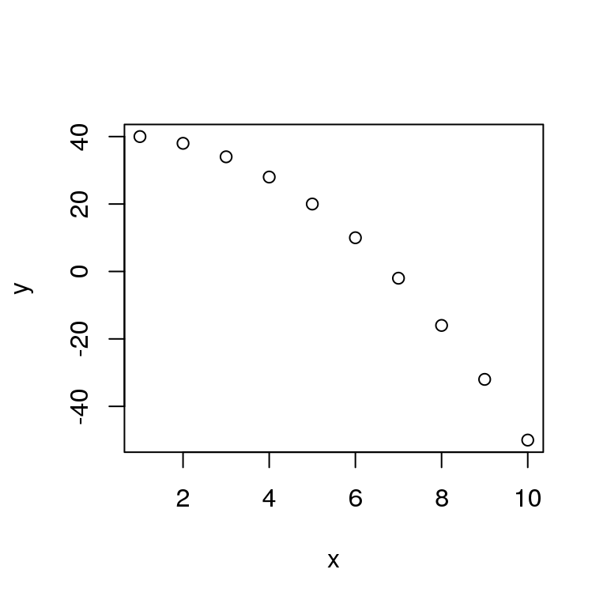

```r
plot(x,y)
```

Para verificar localmente el progreso del artículo utilicé el siguiente código:

```r
render('blogposttest.Rmd',"html_document")
```

El cual genera un archivo local en formato html que podemos revisar con nuestro navegador favorito.

## Paso 3. Publicar en Wordpress

Una vez estamos satisfechos con nuestro borrador en formato .Rmd es el momento de publicarlo. Primero es necesario establecer las opciones de configuración de la conección. El paquete **RWordPress** sólo nos pide tres datos: el nombre de usuario, contraseña y la dirección de acceso al servidor. Para configurar esta información correctamente usamos la función *options* tal y como se muestra a continuación:

```r
# Tell RWordPress how to set the user name, password, and URL for your WordPress site.
options(WordpressLogin = c(usuario1 = 'supercontraseña'),
        WordpressURL = 'https://yoursite.wordpress.com/xmlrpc.php')
```

Hay que prestar atención en el nombre de las opciones (en mi versión del paquete las opciones *WordpressLogin* y *WordpressURL* se escriben con “p” minúscula), si una de estas opciones está mal escrita, o si los datos no son correctos, la conexión no se establece, y aparecen mensajes de error tales como

```
! Error: faultCode:  403  faultString:  Incorrect username or password. !-
```

o

```
! Error in function (type, msg, asError = TRUE)  : Could not resolve host: XXX !-
```

En la opción de la dirección de acceso al servidor hay que incluir la ruta al archivo de configuración XML-RPC, la omisión de esta información genera una larga lista de errores.

¡Ahora si estamos listos para publicar! Para ello invocamos la función **knit2wp** que utiliza knitr para crear el código html y subirlo directamente al sitio WordPress pre-establecido. Entre las opciones de la función debemos especificar el nombre (y dirección) del archivo .Rmd, y podemos además asignarle un título a la entrada del blog, y otros meta-datos como categorías o palabras clave. Yo uso la opción “publish = FALSE” para que la entrada quede almacenada como un borrador que puedo revisar y editar manualmente antes de publicar. Con la opción “publish = TRUE”, el post queda automáticamente publicado.

```r
# Tell knitr to create the html code and upload it to your WordPress site
knit2wp('blogposttest.Rmd', title = 'Ejemplo R + Markdown + WordPress en español',  categories = c('R','Stats'), mt_keywords = c('knitr', 'wordpress'), publish = FALSE)
```

## Listo

Eso es todo lo que se necesita para lograr un primer “post” o entrada en el blog. De ahora en adelante será más fácil generar estas entradas y poblar el sitio con comentarios y recomendaciones relacionadas con el uso de código escrito en R. Para comentarios y sugerencias pueden escribirme a mi cuenta de Twitter [@jrfep](http://twitter.com/jrfep).